# Siniestralidad vial en Barcelona

24 de August de 2026

## El punto de partida

Barcelona publica cada año los accidentes gestionados por su policía local. Entre 2019 y 2025 se registraron **54.954 siniestros**.

La pregunta que guía este proyecto es:

> Si cada vez hay menos accidentes, ¿significa eso que las calles son más seguras?

**Fuente.** Open Data BCN — Ajuntament de Barcelona. Licencia Creative Commons Attribution 4.0. Siete ficheros anuales, 54.954 registros.

## Objetivos

**Objetivo principal**

Determinar en qué medida la reducción del número de accidentes se ha acompañado de una reducción equivalente de su gravedad y qué zonas y momentos concentran el riesgo más alto.

**Objetivos específicos**

1. Describir la evolución temporal del volumen y de la gravedad.
2. Comparar la siniestralidad entre los diez distritos.
3. Caracterizar los patrones temporales intrasemanales.
4. Localizar los puntos de mayor acumulación de accidentes graves.
5. Evaluar la calidad y las limitaciones del conjunto de datos.

## Qué escondían los datos

La unificación de los siete ficheros anuales requirió resolver siete incidencias de homogeneidad. La más relevante afecta directamente a los resultados:

> **En 2024 y 2025 los valores cero se registran como celda vacía.**

En los años anteriores un accidente sin fallecidos escribe un `0` explícito. Interpretar esos blancos como *dato desconocido* habría supuesto descartar el **97 %** de los accidentes recientes al clasificar la gravedad.

Otras incidencias resueltas: cambios en los nombres de columna, columnas que desaparecen a partir de 2021, el valor `-1` como código de ausencia, un campo con formato incompatible en 2020, la inferencia automática de tipos que corrompía el identificador, y espacios sobrantes en los campos de texto.

## Los números del periodo

| Año | Accidentes | Heridos leves | Heridos graves | Fallecidos | % grave o mortal |
| --- | --- | --- | --- | --- | --- |
| 2019 | 10.027 | 11.640 | 202 | 22 | 2.06 |
| 2020 | 6.268 | 7.074 | 142 | 14 | 2.23 |
| 2021 | 7.659 | 8.693 | 167 | 12 | 2.14 |
| 2022 | 7.999 | 8.893 | 176 | 24 | 2.41 |
| 2023 | 7.724 | 8.552 | 228 | 21 | 3.02 |
| 2024 | 7.536 | 8.246 | 254 | 11 | 3.30 |
| 2025 | 7.741 | 8.376 | 249 | 11 | 3.26 |

En total: **1.418** personas heridas graves y **115** fallecidas.

## La pandemia marcó un antes y un después

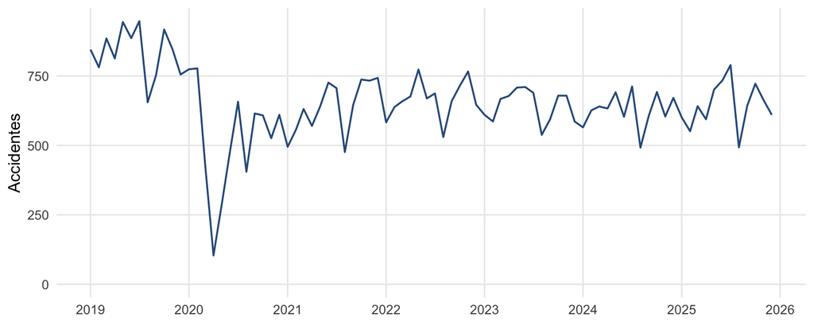

En 2020 los accidentes cayeron un **37.5 %** respecto a 2019. Cinco años después el nivel prepandemia **no se ha recuperado**: 7.741 accidentes en 2025 frente a 10.027 en 2019.

## Pero la gravedad ha ido en dirección contraria

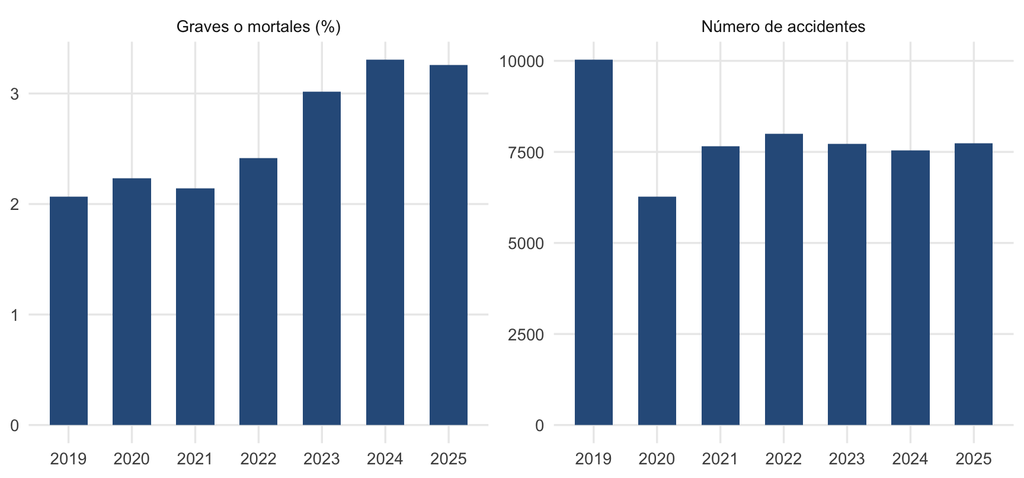

El volumen desciende un **22.8 %**, pero la proporción de siniestros graves o mortales pasa del **2.06 %** al **3.26 %**.

## En términos absolutos

[output not shown]

**Menos muertes, pero más lesiones graves.** Los datos no permiten determinar la causa: verificar la hipótesis más plausible, un cambio en la composición del parque circulante, supondría conocer el tipo de vehículo implicado, información de la que no se dispone en este conjunto.

## Volumen y riesgo no van de la mano

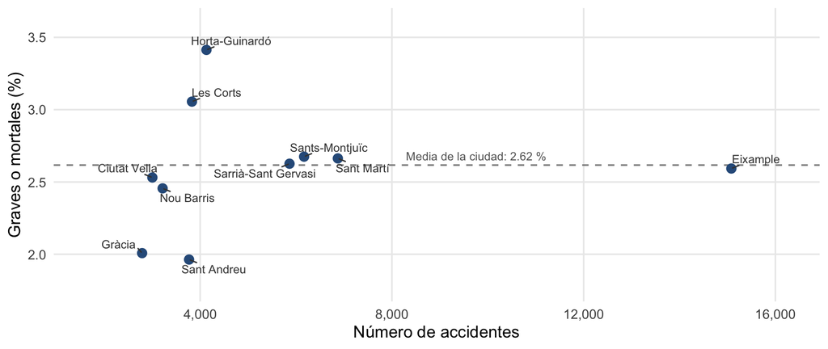

Eixample concentra 15.080 accidentes con una gravedad del 2.59 %. Horta-Guinardó lidera el riesgo (3.41 %) con la cuarta parte de siniestros. **Correlación: 0.1.**

## El mismo patrón en la semana

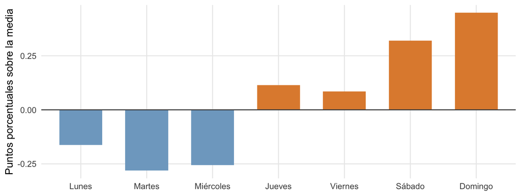

El viernes registra más accidentes que ningún otro día (9.179), pero el domingo presenta la mayor proporción de graves (3.07 %). La hora punta son las **14 h**.

## Dos dimensiones, una misma lectura

El patrón inverso aparece **tanto en el territorio como en el calendario**:

- **Territorio.** Eixample lidera en volumen, Horta-Guinardó en gravedad.
- **Calendario.** El viernes concentra más siniestros, el domingo los más graves.

Dos evidencias independientes apuntan a lo mismo:

**Implicación práctica:** priorizar las actuaciones atendiendo solo al recuento de siniestros dejaría sin atender las zonas y los momentos donde el riesgo por accidente es mayor.

## Lo que estos datos no pueden decir

**Cobertura.** Solo accidentes gestionados por la Guàrdia Urbana. No incluye los siniestros no reportados.

**Ausencia de denominador.** Sin datos de intensidad de tráfico ni de desplazamientos no es posible calcular tasas por vehículo-kilómetro. Todas las cifras se refieren a **accidentes registrados**, no a riesgo por desplazamiento. La comparación entre distritos refleja, por tanto, tanto el riesgo como la exposición.

**Comparabilidad.** El cambio de criterio de registro entre años obliga a interpretar con cuidado la serie completa.

**Sin tipo de vehículo.** Impide contrastar la hipótesis más plausible sobre el aumento de la gravedad.

## Reproducibilidad

Todo el proyecto es reproducible de principio a fin:

- **Datos originales** conservados sin modificar en el repositorio.
- **Código de depuración** comentado, con las siete incidencias documentadas.
- **Dashboard** en dos versiones: interactiva con Shiny y estática autónoma.
- **Informe técnico** generado con knitr.
- **Esta presentación**, escrita en R Markdown.

Las cifras de este documento se calculan al compilar.

**Gracias!**